# Chapter 10 & 11

## Lee Sang Yoon (2016270905)

## 11.13 Exercises

## For these exercises, we will be using the vaccines data in the dslabs package:

```r
library(dslabs)
data(us_contagious_diseases)
```

## 1. Pie charts are appropriate:

### a. When we want to display percentages.

### b. When ggplot2 is not available.

### c. When I am in a bakery.

### d. Never. Barplots and tables are always better.

```r
# answer: d
```

### a. The values are wrong. The final vote was 306 to 232.

### b. The axis does not start at 0. Judging by the length, it appears Trump received 3 times as many votes when, in fact, it was about 30% more.

### c. The colors should be the same.

### d. Percentages should be shown as a pie chart.

```r
# answer: b
```

### a. They provide the same information, so they are both equally as good.

### b. The plot on the right is better because it orders the states alphabetically.

### c. The plot on the right is better because alphabetical order has nothing to do with the disease and by ordering according to actual rate, we quickly see the states with most and least rates.

### d. Both plots should be a pie chart.

```r
# answer: c
```

## 4. To make the plot on the left, we have to reorder the levels of the states’ variables.

```r
library(dslabs)
library(tidyverse)
```

```r
library(NHANES)
library(readxl)
library(dplyr)
library(stringr)
library(splitstackshape)
library(ggpubr)
library(ggplot2)
library(data.table)
library(purrr)
library(readr)
library(readxl)
library(viridis)
library(MetBrewer)
library(rtracklayer)
dat <- us_contagious_diseases |>
  filter(year == 1967 & disease=="Measles" & !is.na(population)) |>
  mutate(rate = count / population * 10000 * 52 / weeks_reporting)
```

## Note what happens when we make a barplot:

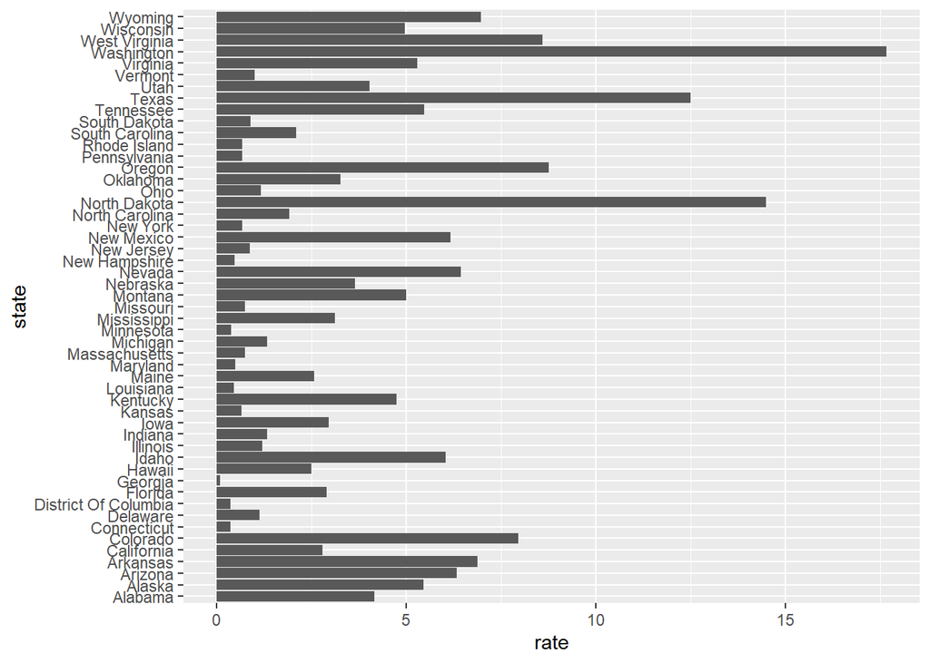

```r
dat |> ggplot(aes(state, rate)) +
  geom_bar(stat="identity") +
  coord_flip()
```

## Define these objects:

```r
state <- dat$state
rate <- dat$count/dat$population*10000*52/dat$weeks_reporting
```

## Redefine the state object so that the levels are re-ordered. Print the new object state and its levels so you can see that the vector is not re-ordered by the levels.

```r
dat <- us_contagious_diseases|>
filter(year == 1967 & disease=="Measles" & !is.na(population))|> mutate(rate = count / population * 10000 * 52 / weeks_reporting)
state <- dat$state
rate <- dat$count/(dat$population/10000)*(52/dat$weeks_reporting)
state <- reorder(state, rate, FUN = mean)
levels(state)
```

```
##  [1] "Georgia"              "District Of Columbia" "Connecticut"
##  [4] "Minnesota"            "Louisiana"            "New Hampshire"
##  [7] "Maryland"             "Kansas"               "New York"
## [10] "Pennsylvania"         "Rhode Island"         "Massachusetts"
## [13] "Missouri"             "New Jersey"           "South Dakota"
## [16] "Vermont"              "Delaware"             "Ohio"
## [19] "Illinois"             "Michigan"             "Indiana"
## [22] "North Carolina"       "South Carolina"       "Hawaii"
## [25] "Maine"                "California"           "Florida"
## [28] "Iowa"                 "Mississippi"          "Oklahoma"
## [31] "Nebraska"             "Utah"                 "Alabama"
## [34] "Kentucky"             "Wisconsin"            "Montana"
## [37] "Virginia"             "Alaska"               "Tennessee"
## [40] "Idaho"                "New Mexico"           "Arizona"
## [43] "Nevada"               "Arkansas"             "Wyoming"
## [46] "Colorado"             "West Virginia"        "Oregon"
## [49] "Texas"                "North Dakota"         "Washington"
```

## 5. Now with one line of code, define the dat table as done above, but change the use mutate to create a rate variable and re-order the state variable so that the levels are re-ordered by this variable. Then make a barplot using the code above, but for this new dat.

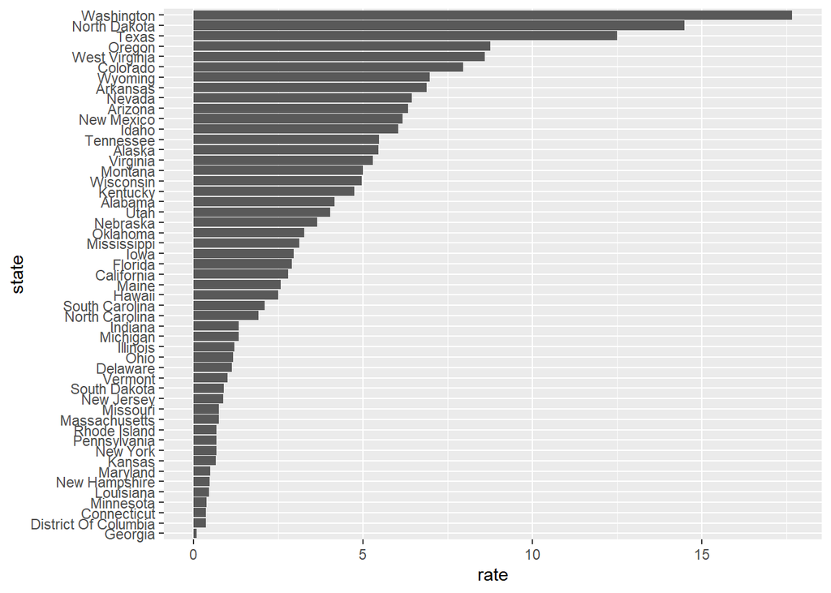

```r
data(us_contagious_diseases)
dat <- us_contagious_diseases|> filter(year == 1967 & disease=="Measles" & count>0 & !is.na(population))|>
  mutate(rate = count / population * 10000 * 52 / weeks_reporting)|>
  mutate(state = reorder(state, rate, FUN = mean))

dat|> ggplot(aes(state, rate)) +
  geom_bar(stat="identity") +
  coord_flip()
```

## 6. Say we are interested in comparing gun homicide rates across regions of the US. We see this plot:

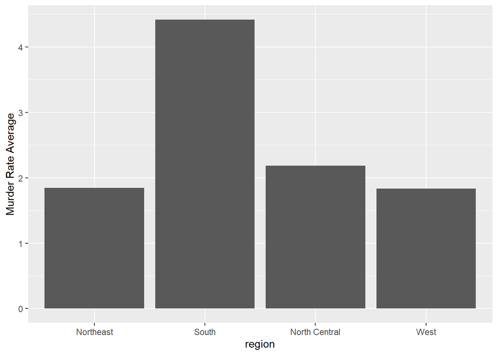

```r
library(dslabs)
data("murders")

murders |> mutate(rate = total/population*100000) |>
group_by(region) |>
summarize(avg = mean(rate)) |>
mutate(region = factor(region)) |>
ggplot(aes(region, avg)) +
geom_bar(stat="identity") +
ylab("Murder Rate Average")
```

## and decide to move to a state in the western region. What is the main problem with this interpretation?

### a. The categories are ordered alphabetically.

### b. The graph does not show standarad errors.

### c. It does not show all the data. We do not see the variability within a region and it’s possible that the safest states are not in the West.

### d. The Northeast has the lowest average.

```r
# answer: c
```

## 7. Make a boxplot of the murder rates defined as

```r
data("murders")
murders |> mutate(rate = total/population*100000)
```

| state | abb | region | population | total | rate |
| --- | --- | --- | --- | --- | --- |
| Alabama | AL | South | 4779736 | 135 | 2.8244238 |
| Alaska | AK | West | 710231 | 19 | 2.6751860 |
| Arizona | AZ | West | 6392017 | 232 | 3.6295273 |
| Arkansas | AR | South | 2915918 | 93 | 3.1893901 |
| California | CA | West | 37253956 | 1257 | 3.3741383 |
| Colorado | CO | West | 5029196 | 65 | 1.2924531 |
| Connecticut | CT | Northeast | 3574097 | 97 | 2.7139722 |
| Delaware | DE | South | 897934 | 38 | 4.2319369 |
| District of Columbia | DC | South | 601723 | 99 | 16.4527532 |
| Florida | FL | South | 19687653 | 669 | 3.3980688 |

[output cut: 41 more lines]

## by region, showing all the points and ordering the regions by their median rate.

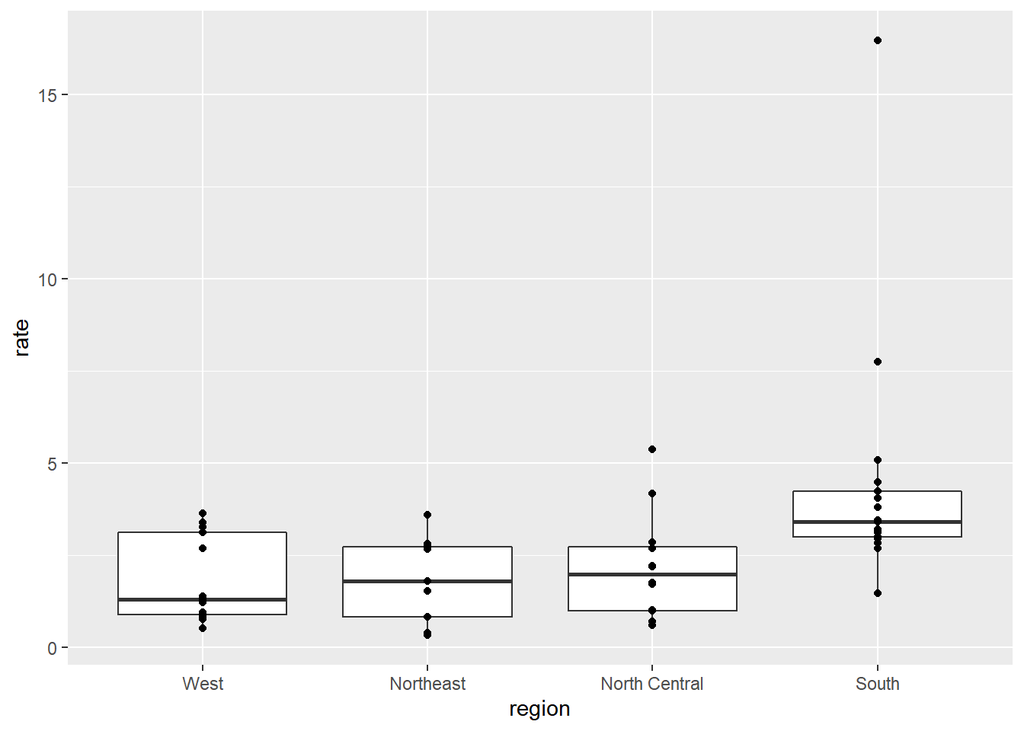

```r
murders |> mutate(rate = total/population*100000)|>
  mutate(region = reorder(region, rate, FUN = median))|>
  ggplot(aes(region,rate)) +
  geom_boxplot() +
  geom_point()
```

## Why is this happening?

### a. Humans are not good at reading pseudo-3D plots.

### b. There must be an error in the code.

### c. The colors confuse us.

### d. Scatterplots should not be used to compare two variables when we have access to 3.

```r
# answer: a
```

## 11.15 Exercises

## 1. Reproduce the image plot we previously made but for smallpox. For this plot, do not include years in which cases were not reported in 10 or more weeks.

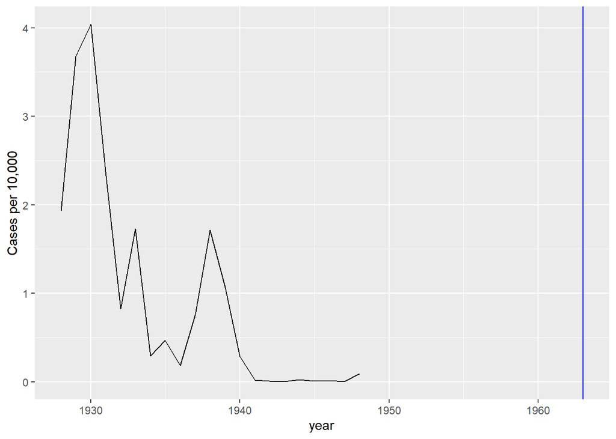

```r
data(us_contagious_diseases)

the_disease <- "Smallpox"
dat <- us_contagious_diseases |>
  filter(!state%in%c("Hawaii","Alaska") & disease == the_disease) |>
  mutate(rate = count / population * 10000 * 52 / weeks_reporting) |>
  mutate(weeks_reporting = ifelse(weeks_reporting>=10, weeks_reporting, NA)) |>
  filter(!is.na(weeks_reporting))


dat |> filter(state == "California" & !is.na(rate)) |>
  ggplot(aes(year, rate)) +
  geom_line() +
  ylab("Cases per 10,000")  +
  geom_vline(xintercept=1963, col = "blue")
```

## 2. Now reproduce the time series plot we previously made, but this time following the instructions of the previous question for smallpox.

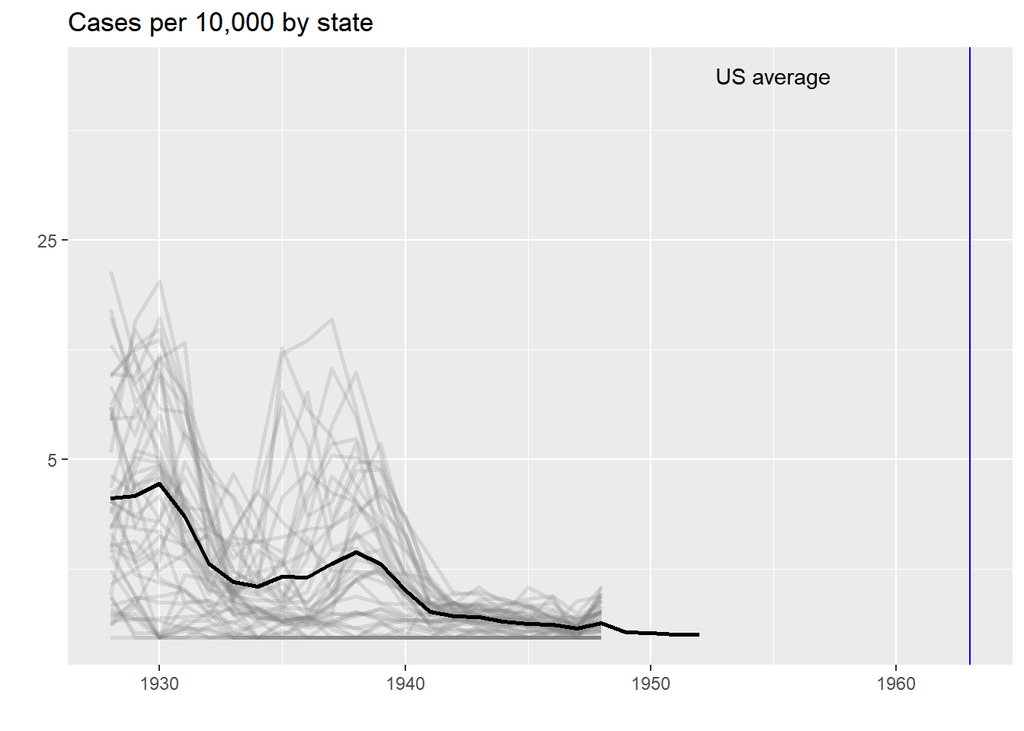

```r
avg <- us_contagious_diseases |>
  filter(disease==the_disease) |> group_by(year) |>
  summarize(us_rate = sum(count, na.rm = TRUE) /
              sum(population, na.rm = TRUE) * 10000)

dat |>
  filter(!is.na(rate)) |>
    ggplot() +
  geom_line(aes(year, rate, group = state),  color = "grey50",
            show.legend = FALSE, alpha = 0.2, size = 1) +
  geom_line(mapping = aes(year, us_rate),  data = avg, size = 1) +
  scale_y_continuous(trans = "sqrt", breaks = c(5, 25, 125, 300)) +
  ggtitle("Cases per 10,000 by state") +
  xlab("") + ylab("") +
  geom_text(data = data.frame(x = 1955, y = 50),
            mapping = aes(x, y, label="US average"),
            color="black") +
  geom_vline(xintercept=1963, col = "blue")
```

## 3. For the state of California, make a time series plot showing rates for all diseases. Include only years with 10 or more weeks reporting. Use a different color for each disease.

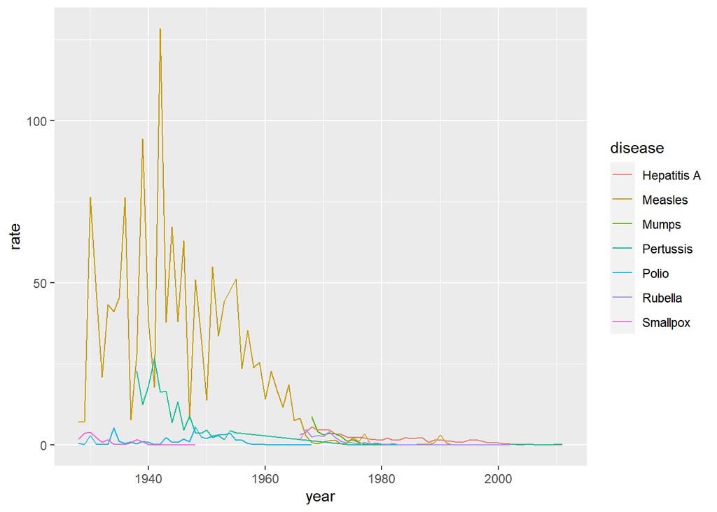

```r
us_contagious_diseases|> filter(state=="California" & weeks_reporting >= 10)|>
  group_by(year, disease)|>
  summarize(rate = sum(count)/sum(population)*10000)|>
  ggplot(aes(year, rate, color = disease)) +
  geom_line()
```

```r
# warning 나오는 건 options(dplyr.summarise.inform= FALSE)로 비활성화 가능
```

## 4. Now do the same for the rates for the US. Hint: compute the US rate by using summarize: the total divided by total population.

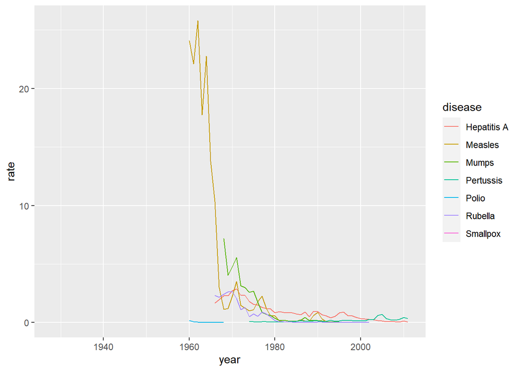

```r
us_contagious_diseases|>
  group_by(year, disease)|>
  summarize(rate = sum(count)/sum(population)*10000)|>
  ggplot(aes(year, rate, color = disease)) +
  geom_line()
```